# Risk Factor Analysis

## Outcome Variable

**Outcome Variable:** wasted

## Predictor Variables

**Intervention Variable:** nrooms

**Adjustment Set:**

unadjusted

## Stratifying Variables

The analysis was stratified on these variable(s):

- agecat
- studyid
- country

## Data Summary

| agecat | studyid | country | nrooms | wasted | n_cell | n | outcome_variable |
| --- | --- | --- | --- | --- | --- | --- | --- |
| Birth | ki0047075b-MAL-ED | BANGLADESH | 4+ | 0 | 11 | 201 | wasted |
| Birth | ki0047075b-MAL-ED | BANGLADESH | 4+ | 1 | 1 | 201 | wasted |
| Birth | ki0047075b-MAL-ED | BANGLADESH | 1 | 0 | 94 | 201 | wasted |
| Birth | ki0047075b-MAL-ED | BANGLADESH | 1 | 1 | 27 | 201 | wasted |
| Birth | ki0047075b-MAL-ED | BANGLADESH | 2 | 0 | 40 | 201 | wasted |
| Birth | ki0047075b-MAL-ED | BANGLADESH | 2 | 1 | 3 | 201 | wasted |
| Birth | ki0047075b-MAL-ED | BANGLADESH | 3 | 0 | 21 | 201 | wasted |
| Birth | ki0047075b-MAL-ED | BANGLADESH | 3 | 1 | 4 | 201 | wasted |
| Birth | ki0047075b-MAL-ED | BRAZIL | 4+ | 0 | 28 | 57 | wasted |
| Birth | ki0047075b-MAL-ED | BRAZIL | 4+ | 1 | 1 | 57 | wasted |
| Birth | ki0047075b-MAL-ED | BRAZIL | 1 | 0 | 0 | 57 | wasted |
| Birth | ki0047075b-MAL-ED | BRAZIL | 1 | 1 | 0 | 57 | wasted |
| Birth | ki0047075b-MAL-ED | BRAZIL | 2 | 0 | 9 | 57 | wasted |
| Birth | ki0047075b-MAL-ED | BRAZIL | 2 | 1 | 1 | 57 | wasted |
| Birth | ki0047075b-MAL-ED | BRAZIL | 3 | 0 | 18 | 57 | wasted |
| Birth | ki0047075b-MAL-ED | BRAZIL | 3 | 1 | 0 | 57 | wasted |
| Birth | ki0047075b-MAL-ED | INDIA | 4+ | 0 | 2 | 39 | wasted |
| Birth | ki0047075b-MAL-ED | INDIA | 4+ | 1 | 0 | 39 | wasted |
| Birth | ki0047075b-MAL-ED | INDIA | 1 | 0 | 14 | 39 | wasted |
| Birth | ki0047075b-MAL-ED | INDIA | 1 | 1 | 3 | 39 | wasted |
| Birth | ki0047075b-MAL-ED | INDIA | 2 | 0 | 14 | 39 | wasted |
| Birth | ki0047075b-MAL-ED | INDIA | 2 | 1 | 2 | 39 | wasted |
| Birth | ki0047075b-MAL-ED | INDIA | 3 | 0 | 4 | 39 | wasted |
| Birth | ki0047075b-MAL-ED | INDIA | 3 | 1 | 0 | 39 | wasted |
| Birth | ki0047075b-MAL-ED | NEPAL | 4+ | 0 | 14 | 25 | wasted |
| Birth | ki0047075b-MAL-ED | NEPAL | 4+ | 1 | 1 | 25 | wasted |
| Birth | ki0047075b-MAL-ED | NEPAL | 1 | 0 | 6 | 25 | wasted |
| Birth | ki0047075b-MAL-ED | NEPAL | 1 | 1 | 0 | 25 | wasted |
| Birth | ki0047075b-MAL-ED | NEPAL | 2 | 0 | 2 | 25 | wasted |
| Birth | ki0047075b-MAL-ED | NEPAL | 2 | 1 | 0 | 25 | wasted |

[output cut: 354 more lines]

The following strata were considered:

- agecat: 24 months, studyid: ki0047075b-MAL-ED, country: BANGLADESH
- agecat: 24 months, studyid: ki0047075b-MAL-ED, country: BRAZIL
- agecat: 24 months, studyid: ki0047075b-MAL-ED, country: INDIA
- agecat: 24 months, studyid: ki0047075b-MAL-ED, country: NEPAL
- agecat: 24 months, studyid: ki0047075b-MAL-ED, country: PERU
- agecat: 24 months, studyid: ki0047075b-MAL-ED, country: SOUTH AFRICA
- agecat: 24 months, studyid: ki0047075b-MAL-ED, country: TANZANIA, UNITED REPUBLIC OF
- agecat: 24 months, studyid: ki1000108-CMC-V-BCS-2002, country: INDIA
- agecat: 24 months, studyid: ki1000108-IRC, country: INDIA
- agecat: 24 months, studyid: ki1017093b-PROVIDE, country: BANGLADESH
- agecat: 24 months, studyid: ki1017093c-NIH-Crypto, country: BANGLADESH
- agecat: 24 months, studyid: ki1113344-GMS-Nepal, country: NEPAL
- agecat: 24 months, studyid: ki1114097-CONTENT, country: PERU
- agecat: 24 months, studyid: ki1135781-COHORTS, country: INDIA
- agecat: 24 months, studyid: kiGH5241-JiVitA-3, country: BANGLADESH
- agecat: 24 months, studyid: kiGH5241-JiVitA-4, country: BANGLADESH
- agecat: 6 months, studyid: ki0047075b-MAL-ED, country: BANGLADESH
- agecat: 6 months, studyid: ki0047075b-MAL-ED, country: BRAZIL
- agecat: 6 months, studyid: ki0047075b-MAL-ED, country: INDIA
- agecat: 6 months, studyid: ki0047075b-MAL-ED, country: NEPAL
- agecat: 6 months, studyid: ki0047075b-MAL-ED, country: PERU
- agecat: 6 months, studyid: ki0047075b-MAL-ED, country: SOUTH AFRICA
- agecat: 6 months, studyid: ki0047075b-MAL-ED, country: TANZANIA, UNITED REPUBLIC OF
- agecat: 6 months, studyid: ki1000108-CMC-V-BCS-2002, country: INDIA
- agecat: 6 months, studyid: ki1000108-IRC, country: INDIA
- agecat: 6 months, studyid: ki1017093b-PROVIDE, country: BANGLADESH
- agecat: 6 months, studyid: ki1017093c-NIH-Crypto, country: BANGLADESH
- agecat: 6 months, studyid: ki1113344-GMS-Nepal, country: NEPAL
- agecat: 6 months, studyid: ki1114097-CONTENT, country: PERU
- agecat: 6 months, studyid: ki1135781-COHORTS, country: INDIA
- agecat: 6 months, studyid: kiGH5241-JiVitA-3, country: BANGLADESH
- agecat: 6 months, studyid: kiGH5241-JiVitA-4, country: BANGLADESH
- agecat: Birth, studyid: ki0047075b-MAL-ED, country: BANGLADESH
- agecat: Birth, studyid: ki0047075b-MAL-ED, country: BRAZIL
- agecat: Birth, studyid: ki0047075b-MAL-ED, country: INDIA
- agecat: Birth, studyid: ki0047075b-MAL-ED, country: NEPAL
- agecat: Birth, studyid: ki0047075b-MAL-ED, country: PERU
- agecat: Birth, studyid: ki0047075b-MAL-ED, country: SOUTH AFRICA
- agecat: Birth, studyid: ki0047075b-MAL-ED, country: TANZANIA, UNITED REPUBLIC OF
- agecat: Birth, studyid: ki1000108-CMC-V-BCS-2002, country: INDIA
- agecat: Birth, studyid: ki1000108-IRC, country: INDIA
- agecat: Birth, studyid: ki1017093b-PROVIDE, country: BANGLADESH
- agecat: Birth, studyid: ki1017093c-NIH-Crypto, country: BANGLADESH
- agecat: Birth, studyid: ki1113344-GMS-Nepal, country: NEPAL
- agecat: Birth, studyid: ki1114097-CONTENT, country: PERU
- agecat: Birth, studyid: ki1135781-COHORTS, country: INDIA
- agecat: Birth, studyid: kiGH5241-JiVitA-3, country: BANGLADESH
- agecat: Birth, studyid: kiGH5241-JiVitA-4, country: BANGLADESH

### Dropped Strata

Some strata were dropped due to rare outcomes:

- agecat: Birth, studyid: ki0047075b-MAL-ED, country: BANGLADESH
- agecat: Birth, studyid: ki0047075b-MAL-ED, country: BRAZIL
- agecat: Birth, studyid: ki0047075b-MAL-ED, country: INDIA
- agecat: Birth, studyid: ki0047075b-MAL-ED, country: NEPAL
- agecat: Birth, studyid: ki0047075b-MAL-ED, country: PERU
- agecat: Birth, studyid: ki0047075b-MAL-ED, country: SOUTH AFRICA
- agecat: Birth, studyid: ki0047075b-MAL-ED, country: TANZANIA, UNITED REPUBLIC OF
- agecat: Birth, studyid: ki1000108-CMC-V-BCS-2002, country: INDIA
- agecat: Birth, studyid: ki1017093b-PROVIDE, country: BANGLADESH
- agecat: Birth, studyid: ki1114097-CONTENT, country: PERU
- agecat: 6 months, studyid: ki0047075b-MAL-ED, country: BANGLADESH
- agecat: 6 months, studyid: ki0047075b-MAL-ED, country: BRAZIL
- agecat: 6 months, studyid: ki0047075b-MAL-ED, country: INDIA
- agecat: 6 months, studyid: ki0047075b-MAL-ED, country: NEPAL
- agecat: 6 months, studyid: ki0047075b-MAL-ED, country: PERU
- agecat: 6 months, studyid: ki0047075b-MAL-ED, country: SOUTH AFRICA
- agecat: 6 months, studyid: ki0047075b-MAL-ED, country: TANZANIA, UNITED REPUBLIC OF
- agecat: 6 months, studyid: ki1000108-CMC-V-BCS-2002, country: INDIA
- agecat: 6 months, studyid: ki1000108-IRC, country: INDIA
- agecat: 6 months, studyid: ki1017093b-PROVIDE, country: BANGLADESH
- agecat: 6 months, studyid: ki1017093c-NIH-Crypto, country: BANGLADESH
- agecat: 6 months, studyid: ki1113344-GMS-Nepal, country: NEPAL
- agecat: 6 months, studyid: ki1114097-CONTENT, country: PERU
- agecat: 6 months, studyid: ki1135781-COHORTS, country: INDIA
- agecat: 24 months, studyid: ki0047075b-MAL-ED, country: BANGLADESH
- agecat: 24 months, studyid: ki0047075b-MAL-ED, country: BRAZIL
- agecat: 24 months, studyid: ki0047075b-MAL-ED, country: INDIA
- agecat: 24 months, studyid: ki0047075b-MAL-ED, country: NEPAL
- agecat: 24 months, studyid: ki0047075b-MAL-ED, country: PERU
- agecat: 24 months, studyid: ki0047075b-MAL-ED, country: SOUTH AFRICA
- agecat: 24 months, studyid: ki0047075b-MAL-ED, country: TANZANIA, UNITED REPUBLIC OF
- agecat: 24 months, studyid: ki1000108-CMC-V-BCS-2002, country: INDIA
- agecat: 24 months, studyid: ki1000108-IRC, country: INDIA
- agecat: 24 months, studyid: ki1017093b-PROVIDE, country: BANGLADESH
- agecat: 24 months, studyid: ki1017093c-NIH-Crypto, country: BANGLADESH
- agecat: 24 months, studyid: ki1113344-GMS-Nepal, country: NEPAL
- agecat: 24 months, studyid: ki1114097-CONTENT, country: PERU
- agecat: 24 months, studyid: ki1135781-COHORTS, country: INDIA

## Methods Detail

We’re interested in the causal parameters $E[Y_a]$ for all values of $a \in \mathcal{A}$. These parameters represent the mean outcome if, possibly contrary to fact, we intervened to set all units to have $A=a$. Under the randomization and positivity assumptions, these are identified by the statistical parameters $\psi_a=E_W[E_{Y|A,W}(Y|A=a,W)]$. In addition, we’re interested in the mean of $Y$, $E[Y]$ under no intervention (the observed mean). We will estimate these parameters by using SuperLearner to fit the relevant likelihood factors – $E_{Y|A,W}(Y|A=a,W)$ and $p(A=a|W)$, and then updating our likelihood fit using a joint TMLE.

For unadjusted analyses ($W=\{\}$), initial likelihoods were estimated using Lrnr_glm to estimate the simple $E(Y|A)$ and Lrnr_mean to estimate $p(A)$. For adjusted analyses, a small library containing Lrnr_glmnet, Lrnr_xgboost, and Lrnr_mean was used.

Having estimated these parameters, we will then use the delta method to estimate relative risks and attributable risks relative to a prespecified baseline level of $A$.

# Results Detail

## Results Plots

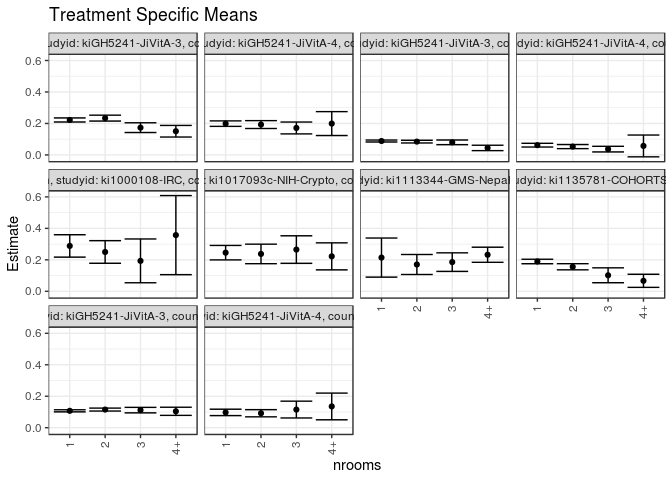

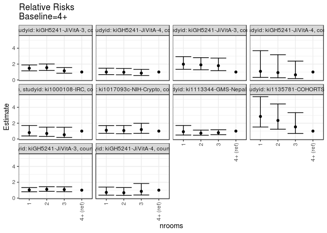

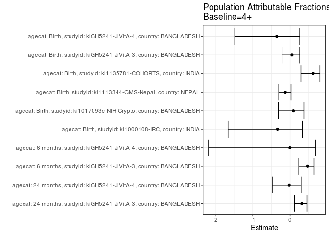

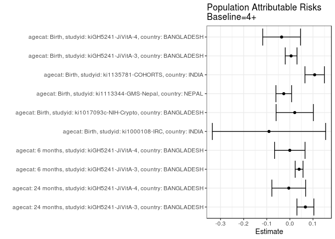

## Results Table

### Parameter: TSM

| agecat | studyid | country | intervention_level | baseline_level | estimate | ci_lower | ci_upper |
| --- | --- | --- | --- | --- | --- | --- | --- |
| Birth | ki1000108-IRC | INDIA | 4+ | NA | 0.3571429 | 0.1057806 | 0.6085051 |
| Birth | ki1000108-IRC | INDIA | 1 | NA | 0.2884615 | 0.2172637 | 0.3596594 |
| Birth | ki1000108-IRC | INDIA | 2 | NA | 0.2500000 | 0.1781673 | 0.3218327 |
| Birth | ki1000108-IRC | INDIA | 3 | NA | 0.1935484 | 0.0542683 | 0.3328284 |
| Birth | ki1017093c-NIH-Crypto | BANGLADESH | 4+ | NA | 0.2222222 | 0.1362703 | 0.3081742 |
| Birth | ki1017093c-NIH-Crypto | BANGLADESH | 1 | NA | 0.2455621 | 0.1996434 | 0.2914808 |
| Birth | ki1017093c-NIH-Crypto | BANGLADESH | 2 | NA | 0.2375691 | 0.1755234 | 0.2996147 |
| Birth | ki1017093c-NIH-Crypto | BANGLADESH | 3 | NA | 0.2653061 | 0.1778341 | 0.3527782 |
| Birth | ki1113344-GMS-Nepal | NEPAL | 4+ | NA | 0.2323232 | 0.1842565 | 0.2803899 |
| Birth | ki1113344-GMS-Nepal | NEPAL | 1 | NA | 0.2142857 | 0.0900943 | 0.3384771 |
| Birth | ki1113344-GMS-Nepal | NEPAL | 2 | NA | 0.1703704 | 0.1069017 | 0.2338390 |
| Birth | ki1113344-GMS-Nepal | NEPAL | 3 | NA | 0.1856287 | 0.1266137 | 0.2446438 |
| Birth | ki1135781-COHORTS | INDIA | 4+ | NA | 0.0666667 | 0.0250085 | 0.1083249 |
| Birth | ki1135781-COHORTS | INDIA | 1 | NA | 0.1896492 | 0.1753277 | 0.2039707 |
| Birth | ki1135781-COHORTS | INDIA | 2 | NA | 0.1558735 | 0.1363621 | 0.1753849 |
| Birth | ki1135781-COHORTS | INDIA | 3 | NA | 0.1019108 | 0.0545830 | 0.1492387 |
| Birth | kiGH5241-JiVitA-3 | BANGLADESH | 4+ | NA | 0.1042296 | 0.0784755 | 0.1299837 |
| Birth | kiGH5241-JiVitA-3 | BANGLADESH | 1 | NA | 0.1073411 | 0.1006661 | 0.1140161 |
| Birth | kiGH5241-JiVitA-3 | BANGLADESH | 2 | NA | 0.1152094 | 0.1058557 | 0.1245630 |
| Birth | kiGH5241-JiVitA-3 | BANGLADESH | 3 | NA | 0.1117571 | 0.0942243 | 0.1292899 |
| Birth | kiGH5241-JiVitA-4 | BANGLADESH | 4+ | NA | 0.1351351 | 0.0502340 | 0.2200362 |
| Birth | kiGH5241-JiVitA-4 | BANGLADESH | 1 | NA | 0.0972028 | 0.0768249 | 0.1175807 |
| Birth | kiGH5241-JiVitA-4 | BANGLADESH | 2 | NA | 0.0918033 | 0.0689534 | 0.1146532 |
| Birth | kiGH5241-JiVitA-4 | BANGLADESH | 3 | NA | 0.1152263 | 0.0617741 | 0.1686785 |
| 6 months | kiGH5241-JiVitA-3 | BANGLADESH | 4+ | NA | 0.0444744 | 0.0273180 | 0.0616308 |
| 6 months | kiGH5241-JiVitA-3 | BANGLADESH | 1 | NA | 0.0883363 | 0.0821418 | 0.0945308 |
| 6 months | kiGH5241-JiVitA-3 | BANGLADESH | 2 | NA | 0.0845309 | 0.0758829 | 0.0931788 |
| 6 months | kiGH5241-JiVitA-3 | BANGLADESH | 3 | NA | 0.0799763 | 0.0651557 | 0.0947969 |
| 6 months | kiGH5241-JiVitA-4 | BANGLADESH | 4+ | NA | 0.0572519 | -0.0119893 | 0.1264931 |
| 6 months | kiGH5241-JiVitA-4 | BANGLADESH | 1 | NA | 0.0620835 | 0.0501886 | 0.0739783 |
| 6 months | kiGH5241-JiVitA-4 | BANGLADESH | 2 | NA | 0.0530179 | 0.0399295 | 0.0661064 |
| 6 months | kiGH5241-JiVitA-4 | BANGLADESH | 3 | NA | 0.0368853 | 0.0189604 | 0.0548101 |
| 24 months | kiGH5241-JiVitA-3 | BANGLADESH | 4+ | NA | 0.1506849 | 0.1138442 | 0.1875257 |
| 24 months | kiGH5241-JiVitA-3 | BANGLADESH | 1 | NA | 0.2222002 | 0.2092614 | 0.2351389 |
| 24 months | kiGH5241-JiVitA-3 | BANGLADESH | 2 | NA | 0.2339181 | 0.2152262 | 0.2526101 |
| 24 months | kiGH5241-JiVitA-3 | BANGLADESH | 3 | NA | 0.1733668 | 0.1423273 | 0.2044063 |
| 24 months | kiGH5241-JiVitA-4 | BANGLADESH | 4+ | NA | 0.1992032 | 0.1231897 | 0.2752167 |
| 24 months | kiGH5241-JiVitA-4 | BANGLADESH | 1 | NA | 0.1988493 | 0.1815956 | 0.2161031 |
| 24 months | kiGH5241-JiVitA-4 | BANGLADESH | 2 | NA | 0.1928808 | 0.1679035 | 0.2178581 |
| 24 months | kiGH5241-JiVitA-4 | BANGLADESH | 3 | NA | 0.1714286 | 0.1337363 | 0.2091209 |

### Parameter: E(Y)

| agecat | studyid | country | intervention_level | baseline_level | estimate | ci_lower | ci_upper |
| --- | --- | --- | --- | --- | --- | --- | --- |
| Birth | ki1000108-IRC | INDIA | NA | NA | 0.2668622 | 0.2198462 | 0.3138781 |
| Birth | ki1017093c-NIH-Crypto | BANGLADESH | NA | NA | 0.2432815 | 0.2116319 | 0.2749310 |
| Birth | ki1113344-GMS-Nepal | NEPAL | NA | NA | 0.2059282 | 0.1745993 | 0.2372572 |
| Birth | ki1135781-COHORTS | INDIA | NA | NA | 0.1740009 | 0.1628660 | 0.1851358 |
| Birth | kiGH5241-JiVitA-3 | BANGLADESH | NA | NA | 0.1096225 | 0.1044939 | 0.1147512 |
| Birth | kiGH5241-JiVitA-4 | BANGLADESH | NA | NA | 0.0994152 | 0.0840401 | 0.1147903 |
| 6 months | kiGH5241-JiVitA-3 | BANGLADESH | NA | NA | 0.0844810 | 0.0796719 | 0.0892901 |
| 6 months | kiGH5241-JiVitA-4 | BANGLADESH | NA | NA | 0.0569712 | 0.0481278 | 0.0658146 |
| 24 months | kiGH5241-JiVitA-3 | BANGLADESH | NA | NA | 0.2179025 | 0.2080266 | 0.2277783 |
| 24 months | kiGH5241-JiVitA-4 | BANGLADESH | NA | NA | 0.1945032 | 0.1812962 | 0.2077102 |

### Parameter: RR

| agecat | studyid | country | intervention_level | baseline_level | estimate | ci_lower | ci_upper |
| --- | --- | --- | --- | --- | --- | --- | --- |
| Birth | ki1000108-IRC | INDIA | 4+ | 4+ | 1.0000000 | 1.0000000 | 1.000000 |
| Birth | ki1000108-IRC | INDIA | 1 | 4+ | 0.8076923 | 0.3831181 | 1.702783 |
| Birth | ki1000108-IRC | INDIA | 2 | 4+ | 0.7000000 | 0.3272990 | 1.497102 |
| Birth | ki1000108-IRC | INDIA | 3 | 4+ | 0.5419355 | 0.1980599 | 1.482855 |
| Birth | ki1017093c-NIH-Crypto | BANGLADESH | 4+ | 4+ | 1.0000000 | 1.0000000 | 1.000000 |
| Birth | ki1017093c-NIH-Crypto | BANGLADESH | 1 | 4+ | 1.1050296 | 0.7191091 | 1.698060 |
| Birth | ki1017093c-NIH-Crypto | BANGLADESH | 2 | 4+ | 1.0690608 | 0.6703726 | 1.704859 |
| Birth | ki1017093c-NIH-Crypto | BANGLADESH | 3 | 4+ | 1.1938776 | 0.7181829 | 1.984653 |
| Birth | ki1113344-GMS-Nepal | NEPAL | 4+ | 4+ | 1.0000000 | 1.0000000 | 1.000000 |
| Birth | ki1113344-GMS-Nepal | NEPAL | 1 | 4+ | 0.9223602 | 0.4984751 | 1.706702 |
| Birth | ki1113344-GMS-Nepal | NEPAL | 2 | 4+ | 0.7333333 | 0.4788895 | 1.122968 |
| Birth | ki1113344-GMS-Nepal | NEPAL | 3 | 4+ | 0.7990107 | 0.5467877 | 1.167579 |
| Birth | ki1135781-COHORTS | INDIA | 4+ | 4+ | 1.0000000 | 1.0000000 | 1.000000 |
| Birth | ki1135781-COHORTS | INDIA | 1 | 4+ | 2.8447378 | 1.5159635 | 5.338211 |
| Birth | ki1135781-COHORTS | INDIA | 2 | 4+ | 2.3381024 | 1.2362126 | 4.422154 |
| Birth | ki1135781-COHORTS | INDIA | 3 | 4+ | 1.5286624 | 0.7017657 | 3.329899 |
| Birth | kiGH5241-JiVitA-3 | BANGLADESH | 4+ | 4+ | 1.0000000 | 1.0000000 | 1.000000 |
| Birth | kiGH5241-JiVitA-3 | BANGLADESH | 1 | 4+ | 1.0298522 | 0.7980639 | 1.328961 |
| Birth | kiGH5241-JiVitA-3 | BANGLADESH | 2 | 4+ | 1.1053421 | 0.8486397 | 1.439694 |
| Birth | kiGH5241-JiVitA-3 | BANGLADESH | 3 | 4+ | 1.0722203 | 0.8059388 | 1.426481 |
| Birth | kiGH5241-JiVitA-4 | BANGLADESH | 4+ | 4+ | 1.0000000 | 1.0000000 | 1.000000 |
| Birth | kiGH5241-JiVitA-4 | BANGLADESH | 1 | 4+ | 0.7193007 | 0.3727940 | 1.387880 |
| Birth | kiGH5241-JiVitA-4 | BANGLADESH | 2 | 4+ | 0.6793443 | 0.3462413 | 1.332911 |
| Birth | kiGH5241-JiVitA-4 | BANGLADESH | 3 | 4+ | 0.8526749 | 0.3948649 | 1.841274 |
| 6 months | kiGH5241-JiVitA-3 | BANGLADESH | 4+ | 4+ | 1.0000000 | 1.0000000 | 1.000000 |
| 6 months | kiGH5241-JiVitA-3 | BANGLADESH | 1 | 4+ | 1.9862278 | 1.3419936 | 2.939732 |
| 6 months | kiGH5241-JiVitA-3 | BANGLADESH | 2 | 4+ | 1.9006634 | 1.2836959 | 2.814157 |
| 6 months | kiGH5241-JiVitA-3 | BANGLADESH | 3 | 4+ | 1.7982550 | 1.1721506 | 2.758793 |
| 6 months | kiGH5241-JiVitA-4 | BANGLADESH | 4+ | 4+ | 1.0000000 | 1.0000000 | 1.000000 |
| 6 months | kiGH5241-JiVitA-4 | BANGLADESH | 1 | 4+ | 1.0843914 | 0.3187896 | 3.688654 |
| 6 months | kiGH5241-JiVitA-4 | BANGLADESH | 2 | 4+ | 0.9260468 | 0.2692828 | 3.184617 |
| 6 months | kiGH5241-JiVitA-4 | BANGLADESH | 3 | 4+ | 0.6442626 | 0.1746252 | 2.376944 |
| 24 months | kiGH5241-JiVitA-3 | BANGLADESH | 4+ | 4+ | 1.0000000 | 1.0000000 | 1.000000 |
| 24 months | kiGH5241-JiVitA-3 | BANGLADESH | 1 | 4+ | 1.4746011 | 1.1484542 | 1.893369 |
| 24 months | kiGH5241-JiVitA-3 | BANGLADESH | 2 | 4+ | 1.5523658 | 1.1949087 | 2.016756 |
| 24 months | kiGH5241-JiVitA-3 | BANGLADESH | 3 | 4+ | 1.1505254 | 0.8480451 | 1.560894 |
| 24 months | kiGH5241-JiVitA-4 | BANGLADESH | 4+ | 4+ | 1.0000000 | 1.0000000 | 1.000000 |
| 24 months | kiGH5241-JiVitA-4 | BANGLADESH | 1 | 4+ | 0.9982237 | 0.6738247 | 1.478798 |
| 24 months | kiGH5241-JiVitA-4 | BANGLADESH | 2 | 4+ | 0.9682616 | 0.6475913 | 1.447719 |
| 24 months | kiGH5241-JiVitA-4 | BANGLADESH | 3 | 4+ | 0.8605714 | 0.5569969 | 1.329600 |

### Parameter: PAR

| agecat | studyid | country | intervention_level | baseline_level | estimate | ci_lower | ci_upper |
| --- | --- | --- | --- | --- | --- | --- | --- |
| Birth | ki1000108-IRC | INDIA | 4+ | NA | -0.0902807 | -0.3356486 | 0.1550872 |
| Birth | ki1017093c-NIH-Crypto | BANGLADESH | 4+ | NA | 0.0210592 | -0.0596162 | 0.1017347 |
| Birth | ki1113344-GMS-Nepal | NEPAL | 4+ | NA | -0.0263950 | -0.0603201 | 0.0075301 |
| Birth | ki1135781-COHORTS | INDIA | 4+ | NA | 0.1073342 | 0.0652317 | 0.1494368 |
| Birth | kiGH5241-JiVitA-3 | BANGLADESH | 4+ | NA | 0.0053929 | -0.0199892 | 0.0307751 |
| Birth | kiGH5241-JiVitA-4 | BANGLADESH | 4+ | NA | -0.0357199 | -0.1174548 | 0.0460150 |
| 6 months | kiGH5241-JiVitA-3 | BANGLADESH | 4+ | NA | 0.0400066 | 0.0230853 | 0.0569279 |
| 6 months | kiGH5241-JiVitA-4 | BANGLADESH | 4+ | NA | -0.0002807 | -0.0662596 | 0.0656982 |
| 24 months | kiGH5241-JiVitA-3 | BANGLADESH | 4+ | NA | 0.0672175 | 0.0305340 | 0.1039010 |
| 24 months | kiGH5241-JiVitA-4 | BANGLADESH | 4+ | NA | -0.0047000 | -0.0778065 | 0.0684065 |

### Parameter: PAF

| agecat | studyid | country | intervention_level | baseline_level | estimate | ci_lower | ci_upper |
| --- | --- | --- | --- | --- | --- | --- | --- |
| Birth | ki1000108-IRC | INDIA | 4+ | NA | -0.3383046 | -1.6601876 | 0.3267170 |
| Birth | ki1017093c-NIH-Crypto | BANGLADESH | 4+ | NA | 0.0865633 | -0.3131281 | 0.3645962 |
| Birth | ki1113344-GMS-Nepal | NEPAL | 4+ | NA | -0.1281757 | -0.3049988 | 0.0246885 |
| Birth | ki1135781-COHORTS | INDIA | 4+ | NA | 0.6168602 | 0.2862315 | 0.7943365 |
| Birth | kiGH5241-JiVitA-3 | BANGLADESH | 4+ | NA | 0.0491955 | -0.2129057 | 0.2546584 |
| Birth | kiGH5241-JiVitA-4 | BANGLADESH | 4+ | NA | -0.3593005 | -1.4804606 | 0.2550989 |
| 6 months | kiGH5241-JiVitA-3 | BANGLADESH | 4+ | NA | 0.4735575 | 0.2308367 | 0.6396842 |
| 6 months | kiGH5241-JiVitA-4 | BANGLADESH | 4+ | NA | -0.0049271 | -2.1807298 | 0.6825010 |
| 24 months | kiGH5241-JiVitA-3 | BANGLADESH | 4+ | NA | 0.3084753 | 0.1192449 | 0.4570495 |
| 24 months | kiGH5241-JiVitA-4 | BANGLADESH | 4+ | NA | -0.0241642 | -0.4779561 | 0.2902953 |